# POF_factor_csv_generate

Author：AbsoluteX

- E-mail：118020043@link.cuhk.edu.cn / l276660317@gmail.com
- start-date: 2022-04-06

/*----- 项目说明 -----*/

- 该项目意在处理东方财富股吧舆情数据并生成因子
- 将对事先获取的股吧标题数据进行处理（该数据仅含有标题，不包含帖子正文），并从各种角度尝试。

```python
import datetime
import re
import time
import pandas as pd
import numpy as np
import seaborn as sns
import matplotlib.pyplot as plt
from tqdm import tqdm
import os
import pickle
sns.set_style('darkgrid')
import joblib
import sys

import matplotlib.ticker as ticker
import warnings
warnings.filterwarnings('ignore')
```

# 1.数据检查

### 1.1数据结构说明

数据来自东方财富股吧，为每天论坛产生的舆论数据。

路径在/dat/cqdata/socialmedia/eastmoney/guba/daily/下，文件命名为日期。

舆论数据的例子如下：

- 20210912 14:48|20210912|162|0|600000,1084183686|建议浦发银行以后不要分红了，拿出分红的钱用于回购自
- 精确到分钟的时间｜日期｜点赞数｜评论数｜股票代码,用户id｜帖子的标题
- 注意，数据只包含帖子的标题，并不包含正文。对于没有标题的帖子，平台会自动提取前25个字符作为标题。这就意味着，这里的数据对于帖子中的舆情存在截断

### 1.2检查数据是否整齐

```python
## this is the sever data path
path = '/dat/cqdata/socialmedia/eastmoney/guba/daily/'
## this is the personal data path, covenient for local analysis
#path = '/Users/absolutex/Library/CloudStorage/OneDrive-个人/data_copy/daily/'

data_num = list()
data_miss = dict()
original_data_list = list()
for i in os.listdir(path):
    if len(i)==8:
        original_data_list.append(i)
original_data_list.sort()

for txt_name in tqdm(original_data_list):
    file_path = path+str(txt_name)
    original_content = list()
    with open(file_path,"r",encoding="utf-8") as f:
        for lines in f.readlines():
            original_content.append(lines[:-1].split('|'))
    data_num.append(int(len(original_content)))
    sentense = list()
    data_miss[txt_name] = list()
    for i in original_content:
        if len(i)!=6:
            data_miss[txt_name].append(i)
```

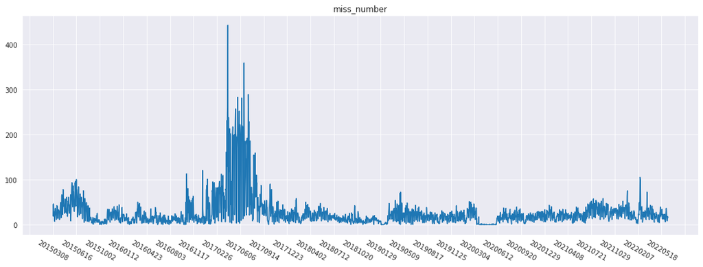

```python
miss_num = list()
for txt_name in original_data_list:
    miss_num.append(int(len(data_miss[txt_name])))

plt.figure(figsize=(18,6))
plt.plot(original_data_list,miss_num)
plt.gca().xaxis.set_major_locator(ticker.MultipleLocator(100))
plt.xticks(rotation=-30)
plt.title('miss_number')

plt.show()
```

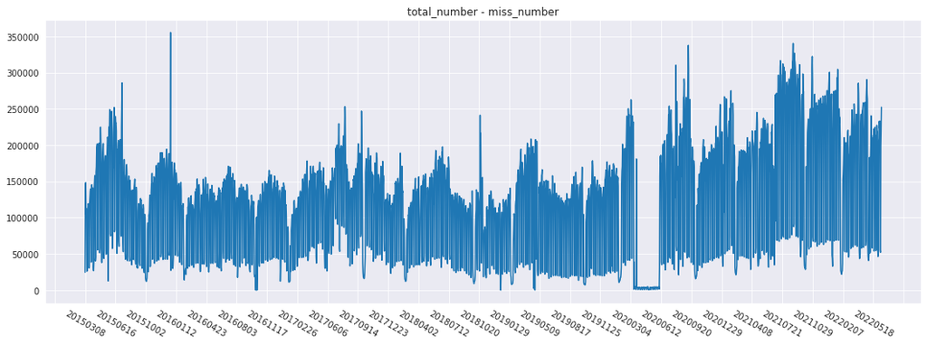

```python
plt.figure(figsize=(18,6))
plt.plot(original_data_list,np.array(data_num)-np.array(miss_num))
plt.gca().xaxis.set_major_locator(ticker.MultipleLocator(100))
plt.xticks(rotation=-30)
plt.title('total_number - miss_number')

plt.show()
```

```python
print('the valid data number <= 700')
for i in range(len(np.array(data_num)-np.array(miss_num))):
    if (np.array(data_num)-np.array(miss_num))[i] <=700:
        print(original_data_list[i])
```

```
the valid data number <= 700
20161008
20161014
20181231
20190423
20200502
20200503
20200504
```

### 发现大量因为文本内存在|导致数据问题的情况

- 20191015 14:49|20191015|827|2|002237,880685301|制/裁土尔其？？？？这个热闹了，英|国月底还硬脱不？
- 同时发现“今日复盘｜xxxxxxx”等案例
- 20171227 12:51|20171226|7853|3|603809,738765203|豪能股份||首日企稳后市有望反弹附图解！（这里有两个“｜”）

将长度>=6的文本归为有效文本重新测试

```python
## this is the sever data path
path = '/dat/cqdata/socialmedia/eastmoney/guba/daily/'
## this is the personal data path, covenient for local analysis
#path = '/Users/absolutex/Library/CloudStorage/OneDrive-个人/data_copy/daily/'

data_num = list()
data_miss_01 = dict()
original_data_list = list()
for i in os.listdir(path):
    if len(i)==8:
        original_data_list.append(i)
original_data_list.sort()

for txt_name in tqdm(original_data_list):
    file_path = path+str(txt_name)
    original_content = list()
    with open(file_path,"r",encoding="utf-8") as f:
        for lines in f.readlines():
            original_content.append(lines[:-1].split('|'))
    data_num.append(int(len(original_content)))
    sentense = list()
    data_miss_01[txt_name] = list()
    for i in original_content:
        if len(i)!=6:
            if len(i)>=7:
                continue
            data_miss_01[txt_name].append(i)
```

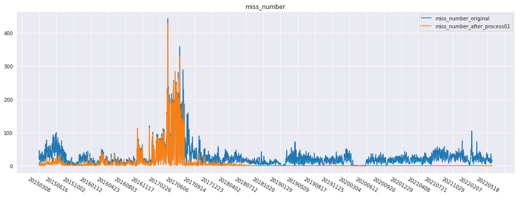

```python
miss_num_01 = list()
for txt_name in original_data_list:
    miss_num_01.append(int(len(data_miss_01[txt_name])))

plt.figure(figsize=(18,6))
plt.plot(original_data_list,miss_num)
plt.plot(original_data_list,miss_num_01)
plt.gca().xaxis.set_major_locator(ticker.MultipleLocator(100))
plt.xticks(rotation=-30)
plt.title('miss_number')
plt.legend(('miss_number_original','miss_number_after_process01'))

plt.show()
```

### 如果只是吧长度为7的元素加入到有效数据中。2018年以后无效数据的出现得到好转，绝大多数miss在个位数，甚至几乎消失为0。但是对于2018年以前，仍然存在大量缺失。进一步打印miss文本寻找问题

```python
"""
#path = '/dat/cqdata/socialmedia/eastmoney/guba/daily/'
path = '/Users/absolutex/Library/CloudStorage/OneDrive-个人/data_copy/daily/'

data_num = list()
data_miss = dict()
data_list = list()
for i in os.listdir(path):
    if len(i)==8:
        if int(i[:4])==2017:
            data_list.append(i)
data_list.sort()
random_choice = np.random.randint(0,(len(data_list)-1),5)
random_choice_data_list = np.array(data_list)[random_choice]

for txt_name in tqdm(random_choice_data_list):
    file_path = path+str(txt_name)
    original_content = list()
    with open(file_path,"r",encoding="utf-8") as f:
        for lines in f.readlines():
            original_content.append(lines[:-1].split('|'))
    data_num.append(int(len(original_content)))
    sentense = list()
    data_miss[txt_name] = list()
    for i in original_content:
        if len(i)<6:
            data_miss[txt_name].append(i)

data_miss
history
"""

data_miss_01['20170416']
```

```
[['√适用不适用 (1)技术开发与创新'],
 [''],
 ['乐视pro3AI版主打方向'],
 [''],
 ['AI+双摄成新品标配，乐Pro3实力升级'],
 [''],
 ['乐视双摄AI智能手机曝光，拍照效果显著提升'],
 ['正是证监会打击的忽悠']]
```

### 发现剩余文本多是只有舆情文本没有其它信息的数据

也就是说该数据没有标注所适用的股票，放弃对该数据的处理

# 2.数据处理

## 2.1数据词频处理

使用hanlp进行处理并对词性进行分类标注统计，详情参考代码sentense_character.py文件

该库会对每一条舆情数据进行处理，并存储为pkl文件，处理结果如下所示：

```python
#path = os.getcwd()+'/obj/'
path = '/home/cqintern08/AbsoluteX_intern/Absolute_Alpha/obj/'
data_list = os.listdir(path)

data_list[0]
```

```
'pos_sentense_day20190704.pkl'
```

## 2.2生成词频csv统计文件

```python
data_name = data_list[0]
pos_sentense_day=joblib.load(path+data_name)
data_date = int(data_name[-12:-4])

#读取并且检查数据是否对齐，如果完全对齐则表示是一一对应的关系
#如果数据没有对齐，会立刻退出运行程序
dict_names = ['tok/fine','pos/ctb','pos/pku','pos/863','last_change',
             'build_day','up_opinion','comments_num','stock_code','user_id']
dict_len = len(pos_sentense_day['tok/fine'])
for dict_name in dict_names:
    if dict_len != len(pos_sentense_day[dict_name]):
        print('/*----- exist data not aligned!!!!! -----*/')
        sys.exit()

"""
#根据每天的舆情数据创建pandas表单，生成词性频率表单
#这里采用pku标准，并主观删除了部分可能没有作用的词性，对应词性如下所示
A：形容词
D：副词
E：叹词
M：数词
N：名词
V：动词
Y：语气词
"""
pos_sentense_day['word_num_total'] = np.zeros(dict_len)
word_tags = ['A','D','E','I','M','N','V','Y']
for word_tag in word_tags:
    pos_sentense_day[word_tag] = np.zeros(dict_len)
#开始逐行统计出现词性的次数
for i in range(dict_len):
    pos_list = pos_sentense_day['pos/pku'][i]
    pos_sentense_day['word_num_total'][i] = len(pos_list)
    for tag in pos_list:
        if tag[0].upper() in word_tags:
            pos_sentense_day[tag[0].upper()][i] = pos_sentense_day[tag[0].upper()][i]+1

freq_table = pd.DataFrame(pos_sentense_day).drop(['tok/fine','pos/ctb','pos/pku','pos/863'],axis=1)
freq_table['word_num_selected'] = freq_table[['A','D','E','I','M','N','V','Y']].sum(axis=1)

freq_table.head()
```

|  | last_change | build_day | up_opinion | comments_num | stock_code | user_id | word_num_total | A | D | E | I | M | N | V | Y | word_num_selected |
| --- | --- | --- | --- | --- | --- | --- | --- | --- | --- | --- | --- | --- | --- | --- | --- | --- |
| 0 | 20190704 23:34 | 20190704 | 1451 | 4 | 600000 | 850010392 | 11.0 | 1.0 | 0.0 | 0.0 | 0.0 | 0.0 | 4.0 | 3.0 | 0.0 | 8.0 |
| 1 | 20190704 23:10 | 20181228 | 260万 | 2.8万 | 600000 | 799607080 | 18.0 | 0.0 | 2.0 | 0.0 | 0.0 | 0.0 | 4.0 | 4.0 | 0.0 | 10.0 |
| 2 | 20190704 23:07 | 20190704 | 3775 | 28 | 600000 | 849861876 | 12.0 | 1.0 | 0.0 | 0.0 | 0.0 | 0.0 | 5.0 | 4.0 | 0.0 | 10.0 |
| 3 | 20190704 23:04 | 20190704 | 2345 | 19 | 600000 | 849864409 | 10.0 | 0.0 | 0.0 | 0.0 | 0.0 | 1.0 | 1.0 | 3.0 | 0.0 | 5.0 |
| 4 | 20190704 22:44 | 20190704 | 1108 | 2 | 600000 | 850011759 | 9.0 | 0.0 | 0.0 | 0.0 | 0.0 | 2.0 | 1.0 | 2.0 | 1.0 | 6.0 |

```python
#存储成csv文件并保存在路径freq_csv下
#freq_table.to_csv('freq_csv/'+'freq'+str(data_date)+'.csv',index=False)
```

### working log

后续出现的bug

清洗细节请见章节4.1

# 3.因子生成及测试

## 3.1自然日和交易日之间的映射

因为舆情数据的截取是按照自然日进行截取，而我们在因子回测中更多的使用的是交易日。生成因子日期对照表，将自然日的舆情数据与产生效果的因子交易日一一对应，以实现数据的特殊处理。

```python
### history_price is got from Wind
### here is only used to get all trading day info
history_price = pd.read_csv('history_price.csv')
history_price = history_price.loc[history_price.date<='2020-12-31',]
path = '/home/cqintern08/AbsoluteX_new/Public_Opinion_Factor/freq_csv/'
data_list = os.listdir(path)
data_list.sort()
date_list = list()
for file_name in data_list:
    if file_name !='.DS_Store':
        date_list.append(file_name[-12:-4])
trade_day = history_price.date.apply(lambda x: x[:4]+x[5:7]+x[8:10]).unique().tolist()
trade_day.sort()

date_compar = dict()
temp_date = date_list.copy()
for i in range(len(trade_day)):
    today = trade_day[i]
    temp_list = list()
    for j in temp_date:
        if j < today:
            temp_list.append(j)
    if len(temp_list)>=1:
        date_compar[today] = temp_list
        for j in temp_list:
            temp_date.remove(j)
cnt=0
for (i,j) in date_compar.items():
    print(i,'use POP data in  ',j)
    cnt+=1
    if cnt>=11:
        break
```

```
20170103 use POP data in   ['20170101', '20170102']
20170104 use POP data in   ['20170103']
20170105 use POP data in   ['20170104']
20170106 use POP data in   ['20170105']
20170109 use POP data in   ['20170106', '20170107', '20170108']
20170110 use POP data in   ['20170109']
20170111 use POP data in   ['20170110']
20170112 use POP data in   ['20170111']
20170113 use POP data in   ['20170112']
20170116 use POP data in   ['20170113', '20170114', '20170115']
20170117 use POP data in   ['20170116']
```

## 3.2股票覆盖率检验

```
stock coverage of 20181112 is 736
stock coverage of 20181113 is 729
stock coverage of 20190423 is 3
stock coverage of 20200316 is 66
stock coverage of 20200317 is 70
stock coverage of 20200318 is 66
stock coverage of 20200319 is 61
stock coverage of 20200322 is 99
stock coverage of 20200324 is 78
stock coverage of 20200325 is 73
stock coverage of 20200326 is 81
stock coverage of 20200329 is 98
stock coverage of 20200330 is 76
stock coverage of 20200331 is 73
stock coverage of 20200401 is 75
stock coverage of 20200402 is 73
stock coverage of 20200406 is 98
stock coverage of 20200407 is 75
stock coverage of 20200408 is 81
stock coverage of 20200409 is 76
stock coverage of 20200412 is 99
stock coverage of 20200413 is 81
stock coverage of 20200414 is 70
stock coverage of 20200415 is 74
stock coverage of 20200416 is 72
stock coverage of 20200419 is 99
stock coverage of 20200420 is 83
stock coverage of 20200421 is 79
stock coverage of 20200422 is 76
stock coverage of 20200423 is 76
stock coverage of 20200426 is 96
stock coverage of 20200427 is 77
stock coverage of 20200428 is 69
stock coverage of 20200429 is 65
stock coverage of 20200505 is 99
stock coverage of 20200506 is 77
stock coverage of 20200507 is 75
stock coverage of 20200510 is 97
stock coverage of 20200511 is 81
stock coverage of 20200512 is 79
stock coverage of 20200513 is 66
stock coverage of 20200514 is 71
stock coverage of 20200517 is 97
stock coverage of 20200518 is 74
stock coverage of 20200519 is 74
stock coverage of 20200520 is 73
stock coverage of 20200521 is 70
stock coverage of 20200524 is 95
stock coverage of 20200525 is 74
stock coverage of 20200526 is 68
stock coverage of 20200527 is 69
stock coverage of 20200528 is 74
stock coverage of 20200531 is 98
stock coverage of 20200601 is 75
stock coverage of 20200602 is 75
stock coverage of 20200603 is 73
stock coverage of 20200604 is 70
stock coverage of 20200723 is 729
stock coverage of 20200810 is 642
```

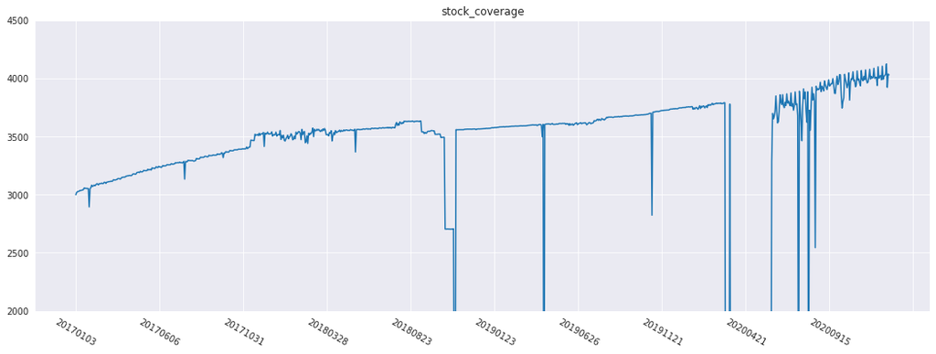

```python
path = '/home/cqintern08/AbsoluteX_new/Public_Opinion_Factor/freq_csv/'
stock_coverage = list()
for file_name_list in date_compar.values():
    trade_day_POP = None
    for one_day in file_name_list:
        temp = pd.read_csv(path+'freq'+one_day+'.csv')
        try:
            trade_day_POP = pd.concat([trade_day_POP,temp])
        except:
            trade_day_POP = temp

    stock_number = list()
    for code in trade_day_POP.stock_code.unique():
        try:
            if int(code) not in stock_number:
                stock_number.append(int(code))
        except:
            continue
    stock_coverage_num = len(stock_number)
    stock_coverage.append(stock_coverage_num)

    ### only print if stock coverage less than 1500
    if stock_coverage_num <= 1500:
        print('stock coverage of',one_day,'is',stock_coverage_num)
    if stock_coverage_num > 5000:
        print('stock number exceed 5000, get bug! re-check the data!')
        break

plt.figure(figsize=(18,6))
plt.plot(date_compar.keys(),stock_coverage)
plt.ylim(2000,4500)
plt.gca().xaxis.set_major_locator(ticker.MultipleLocator(100))
plt.xticks(rotation=-30)
plt.title('stock_coverage')
plt.show()
```

# 4.因子生成

## 4.1清理stock code数据 并生成因子表单

```python
def transf_code(x):
    x = str(int(x))
    if len(x)<6:
        start = ''
        for i in range(6-len(x)):
            start = start+'0'
        x = start+x
    return x
def judge_int(x):
    try:
        z = int(x)
        return True
    except:
        return False

all_day_factor = None
path = os.getcwd()+'/freq_csv/'
for i in tqdm(range(len(date_compar.values()))):
    file_name_list = list(date_compar.values())[i]
    trade_day = list(date_compar.keys())[i]
    trade_day_POP = None
    for one_day in file_name_list:
        temp = pd.read_csv(path+'freq'+one_day+'.csv')
        try:
            trade_day_POP = pd.concat([trade_day_POP,temp]).reset_index(drop=True)
        except:
            trade_day_POP = temp

    trade_day_POP = trade_day_POP.loc[trade_day_POP.stock_code.apply(lambda x: judge_int(x)),].reset_index(drop=True)
    trade_day_POP['stock_code'] = trade_day_POP.stock_code.apply(lambda x: transf_code(x))
    """
    重新分配因子值对应的交易日，有多种情况，特在代码中说明：

        情况1:
    20170104 use POP data in ['20170103']
    代表20170103中的数据，只有15：00之前的对20170104产生影响
    20170103数据15:00之后的数据对20170104的下一个交易日产生影响

        情况2:
    20170109 use POP data in   ['20170106', '20170107', '20170108']
    代表20170106全天、20170107全天、20170108的15:00之前对20170109产生影响
    20170108的15:00之后的数据对20170109的下一个交易日产生影响

    笔者注：
    之所以严格卡住15:00这个时间段，是参考量价因子的回测逻辑
    同时避免未来数据对回测结果产生影响
    事实上，笔者通过lag=1的方法完全消除未来数据影响，甚至产生因子滞后，因子效果出现衰减但仍在接受范围
    """
    try:
        next_trade_day = list(date_compar.keys())[i+1]
    except:
        next_trade_day = int(list(date_compar.keys())[i])+1
        print('only can appear once!')
    trade_day_POP['last_hour'] = trade_day_POP.last_change.apply(lambda x: int(str(x)[-5:-3]))
    trade_day_POP['last_day'] = trade_day_POP.last_change.apply(lambda x: int(str(x)[:8]))
    threshold_day = int(list(date_compar.values())[i][-1])
    trade_day_POP['trade_day'] = trade_day
    trade_day_POP['help_index'] = trade_day_POP.last_day.apply(lambda x: int(x==threshold_day))
    trade_day_POP['help_index'] = trade_day_POP['help_index'] * trade_day_POP.last_hour.apply(lambda x: int(x>=15))
    factor_day = list()
    for i in trade_day_POP.help_index:
        if i==0:
            factor_day.append(trade_day)
        else:
            factor_day.append(next_trade_day)
    trade_day_POP['trade_day'] = factor_day
    '''
    trade_day_POP['A'] = trade_day_POP.A/trade_day_POP.word_num_total
    trade_day_POP['D'] = trade_day_POP.D/trade_day_POP.word_num_total
    trade_day_POP['E'] = trade_day_POP.E/trade_day_POP.word_num_total
    trade_day_POP['I'] = trade_day_POP.I/trade_day_POP.word_num_total
    trade_day_POP['M'] = trade_day_POP.M/trade_day_POP.word_num_total
    trade_day_POP['N'] = trade_day_POP.N/trade_day_POP.word_num_total
    trade_day_POP['V'] = trade_day_POP.V/trade_day_POP.word_num_total
    trade_day_POP['Y'] = trade_day_POP.Y/trade_day_POP.word_num_total
    '''
    day_factor = trade_day_POP.groupby(['stock_code','trade_day']).aggregate({'A':'sum','D':'sum','E':'sum',
                                                                              'I':'sum','M':'sum','N':'sum',
                                                                              'V':'sum','Y':'sum','word_num_total':'sum',
                                                                              'word_num_total':'sum',
                                                                              'user_id':'unique'})


    day_factor['user_id'] = day_factor.user_id.apply(lambda x: len(x))
    day_factor = day_factor.reset_index(drop=False)
    try:
        all_day_factor = pd.concat([all_day_factor,day_factor])
    except:
        all_day_factor = day_factor
```

```
only can appear once!
```

```python
#all_day_factor = all_day_factor.reset_index(drop=False)
all_day_factor = all_day_factor.groupby(['stock_code','trade_day']).aggregate({'A':'sum','D':'sum','E':'sum',
                                                                            'I':'sum','M':'sum','N':'sum',
                                                                            'V':'sum','Y':'sum','word_num_total':'sum',
                                                                            'word_num_total':'sum',
                                                                            'user_id':'sum'})
all_day_factor['A'] = all_day_factor.A/all_day_factor.word_num_total
all_day_factor['D'] = all_day_factor.D/all_day_factor.word_num_total
all_day_factor['E'] = all_day_factor.E/all_day_factor.word_num_total
all_day_factor['I'] = all_day_factor.I/all_day_factor.word_num_total
all_day_factor['M'] = all_day_factor.M/all_day_factor.word_num_total
all_day_factor['N'] = all_day_factor.N/all_day_factor.word_num_total
all_day_factor['V'] = all_day_factor.V/all_day_factor.word_num_total
all_day_factor['Y'] = all_day_factor.Y/all_day_factor.word_num_total
all_day_factor.head()
```

| stock_code | trade_day | A | D | E | I | M | N | V | Y | word_num_total | user_id |
| --- | --- | --- | --- | --- | --- | --- | --- | --- | --- | --- | --- |
| 000001 | 20201232 | 0.040678 | 0.074576 | 0.000000 | 0.003390 | 0.030508 | 0.267797 | 0.237288 | 0.016949 | 295.0 | 27 |
|  | 20170103 | 0.033435 | 0.091185 | 0.000000 | 0.000000 | 0.045593 | 0.218845 | 0.240122 | 0.024316 | 329.0 | 30 |
|  | 20170104 | 0.048832 | 0.063694 | 0.000000 | 0.000000 | 0.063694 | 0.299363 | 0.239915 | 0.012739 | 471.0 | 44 |
|  | 20170105 | 0.050671 | 0.068554 | 0.000000 | 0.002981 | 0.041729 | 0.256334 | 0.262295 | 0.017884 | 671.0 | 60 |
|  | 20170106 | 0.034913 | 0.052369 | 0.002494 | 0.002494 | 0.077307 | 0.249377 | 0.231920 | 0.017456 | 401.0 | 40 |

```python
all_day_factor = all_day_factor.reset_index(drop=False)
all_day_factor['trade_day'] = pd.to_datetime(all_day_factor.trade_day)
print(all_day_factor.info())
all_day_factor.to_csv('all_day_factor.csv',index=False)
all_day_factor.head()
```

```
<class 'pandas.core.frame.DataFrame'>
RangeIndex: 3276636 entries, 0 to 3276635
Data columns (total 12 columns):
 #   Column          Dtype
---  ------          -----
 0   stock_code      object
 1   trade_day       datetime64[ns]
 2   A               float64
 3   D               float64
 4   E               float64
 5   I               float64
 6   M               float64
 7   N               float64
 8   V               float64
 9   Y               float64
 10  word_num_total  float64
 11  user_id         int64
dtypes: datetime64[ns](1), float64(9), int64(1), object(1)
memory usage: 300.0+ MB
None
```

|  | stock_code | trade_day | A | D | E | I | M | N | V | Y | word_num_total | user_id |
| --- | --- | --- | --- | --- | --- | --- | --- | --- | --- | --- | --- | --- |
| 0 | 000001 | 1970-01-01 00:00:00.020201232 | 0.040678 | 0.074576 | 0.000000 | 0.003390 | 0.030508 | 0.267797 | 0.237288 | 0.016949 | 295.0 | 27 |
| 1 | 000001 | 2017-01-03 00:00:00.000000000 | 0.033435 | 0.091185 | 0.000000 | 0.000000 | 0.045593 | 0.218845 | 0.240122 | 0.024316 | 329.0 | 30 |
| 2 | 000001 | 2017-01-04 00:00:00.000000000 | 0.048832 | 0.063694 | 0.000000 | 0.000000 | 0.063694 | 0.299363 | 0.239915 | 0.012739 | 471.0 | 44 |
| 3 | 000001 | 2017-01-05 00:00:00.000000000 | 0.050671 | 0.068554 | 0.000000 | 0.002981 | 0.041729 | 0.256334 | 0.262295 | 0.017884 | 671.0 | 60 |
| 4 | 000001 | 2017-01-06 00:00:00.000000000 | 0.034913 | 0.052369 | 0.002494 | 0.002494 | 0.077307 | 0.249377 | 0.231920 | 0.017456 | 401.0 | 40 |

```python
close = pd.read_csv('/home/cqintern08/AbsoluteX_new/Public_Opinion_Factor/weighted_close.csv').\
    set_index('Unnamed: 0').dropna(how='all', axis=1)
print(f'close data loaded! with shape {close.shape}')
close = close.drop('日期', axis=1)

def generate_factor_csv(factor_name,all_day_factor_path,close):
    all_day_factor = pd.read_csv(all_day_factor_path)
    stock_code_map = pd.DataFrame(close.index)
    all_day_factor['stock_code'] = all_day_factor['stock_code'].astype(str)
    stock_code_map['code_number'] = stock_code_map['Unnamed: 0'].map(lambda x: str(x)[:6])
    factor_test = pd.merge(all_day_factor,stock_code_map,
                            left_on=['stock_code'],right_on=['code_number'],
                            how='inner')
    factor_test['trade_day'] = factor_test['trade_day'].map(lambda x: str(x)[:4]+str(x)[5:7]+str(x)[8:10])
    joint_cols = list(set(close.columns) & set(factor_test['trade_day'].unique()))
    joint_cols.sort()
    joint_rows = list(set(close.index) & set(factor_test['Unnamed: 0'].unique()))
    joint_rows.sort()
    factor_test = factor_test.loc[factor_test.trade_day.apply(lambda x: x in joint_cols),]
    f = factor_test[['Unnamed: 0','trade_day',factor_name]].set_index(['Unnamed: 0','trade_day']).unstack()

    structure = close[joint_cols]
    idx = pd.IndexSlice
    structure = structure.loc[idx[joint_rows],]
    structure = structure.sort_index()
    f = f.sort_index()
    f = pd.DataFrame(f.values,columns=structure.columns,index=structure.index)
    f = f.dropna(how='all', axis=1)
    f = f.replace([-np.inf, np.inf], np.nan).dropna(how='all', axis=1)
    ### remember the date of factor-value is the next tading day it make difference
    ### 2017-01-02 15:00之前产生的因子值，被标注在了交易日2017-01-03，所以我们要shift(-1)
    factor = f.shift(-1,axis=1)
    return factor
```

```
close data loaded! with shape (4112, 4111)
```

```python
all_day_factor_path = '/home/cqintern08/AbsoluteX_new/Public_Opinion_Factor/all_day_factor.csv'
possible_factor_name = ['A','D','E','I','M','N','V','Y','word_num_total','user_id']

for factor_name in possible_factor_name:
    factorvalue = generate_factor_csv(factor_name,all_day_factor_path,close)
    factorvalue.to_csv('/home/cqintern08/AbsoluteX_new/Public_Opinion_Factor/factorvalue/'+factor_name+'_factorvalue.csv')
```

```python
factorvalue
```

| Unnamed: 0 | 20170103 | 20170104 | 20170105 | 20170106 | 20170109 | 20170110 | 20170111 | 20170112 | 20170113 | 20170116 | ... | 20201117 | 20201118 | 20201119 | 20201120 | 20201123 | 20201124 | 20201125 | 20201126 | 20201127 | 20201130 |
| --- | --- | --- | --- | --- | --- | --- | --- | --- | --- | --- | --- | --- | --- | --- | --- | --- | --- | --- | --- | --- | --- |
| 300001.SZ | 24.0 | 25.0 | 26.0 | 37.0 | 12.0 | 32.0 | 36.0 | 47.0 | 33.0 | 16.0 | ... | 73.0 | 40.0 | 78.0 | 211.0 | 100.0 | 231.0 | 169.0 | 206.0 | 297.0 | NaN |
| 300002.SZ | 13.0 | 29.0 | 25.0 | 44.0 | 20.0 | 22.0 | 13.0 | 17.0 | 58.0 | 29.0 | ... | 74.0 | 45.0 | 60.0 | 407.0 | 180.0 | 183.0 | 105.0 | 114.0 | 162.0 | NaN |
| 300003.SZ | 10.0 | 20.0 | 8.0 | 39.0 | 15.0 | 13.0 | 15.0 | 32.0 | 29.0 | 15.0 | ... | 157.0 | 147.0 | 112.0 | 249.0 | 189.0 | 188.0 | 199.0 | 430.0 | 255.0 | NaN |
| 300004.SZ | 36.0 | 24.0 | 25.0 | 52.0 | 13.0 | 17.0 | 40.0 | 41.0 | 71.0 | 38.0 | ... | 22.0 | 22.0 | 9.0 | 25.0 | 11.0 | 5.0 | 9.0 | 18.0 | 28.0 | NaN |
| 300005.SZ | 14.0 | 26.0 | 4.0 | 16.0 | 2.0 | 13.0 | 7.0 | 8.0 | 16.0 | 8.0 | ... | 34.0 | 18.0 | 14.0 | 79.0 | 22.0 | 48.0 | 34.0 | 28.0 | 46.0 | NaN |
| ... | ... | ... | ... | ... | ... | ... | ... | ... | ... | ... | ... | ... | ... | ... | ... | ... | ... | ... | ... | ... | ... |
| 688600.SH | NaN | NaN | NaN | NaN | NaN | NaN | NaN | NaN | NaN | NaN | ... | 13.0 | 9.0 | 9.0 | 13.0 | 7.0 | 9.0 | 5.0 | 10.0 | 9.0 | NaN |
| 688777.SH | NaN | NaN | NaN | NaN | NaN | NaN | NaN | NaN | NaN | NaN | ... | NaN | NaN | NaN | NaN | NaN | 160.0 | 176.0 | 117.0 | 208.0 | NaN |
| 688788.SH | NaN | NaN | NaN | NaN | NaN | NaN | NaN | NaN | NaN | NaN | ... | 23.0 | 33.0 | 47.0 | 80.0 | 41.0 | 48.0 | 23.0 | 34.0 | 76.0 | NaN |
| 688981.SH | NaN | NaN | NaN | NaN | NaN | NaN | NaN | NaN | NaN | NaN | ... | 176.0 | 129.0 | 104.0 | 195.0 | 105.0 | 98.0 | 101.0 | 138.0 | 312.0 | NaN |
| 689009.SH | NaN | NaN | NaN | NaN | NaN | NaN | NaN | NaN | NaN | NaN | ... | 154.0 | 119.0 | 90.0 | 266.0 | 73.0 | 84.0 | 73.0 | 113.0 | 145.0 | NaN |

2656 rows × 949 columns